# Peer Assessment I

First, let us load the data and necessary packages:

```r
load("ames_train.Rdata")
library(MASS)
library(dplyr)
```

```r
library(ggplot2)
library(scales)
library(GGally)
library(BAS)
```

# 1

Make a labeled histogram (with 30 bins) of the ages of the houses in the data set, and describe the distribution.

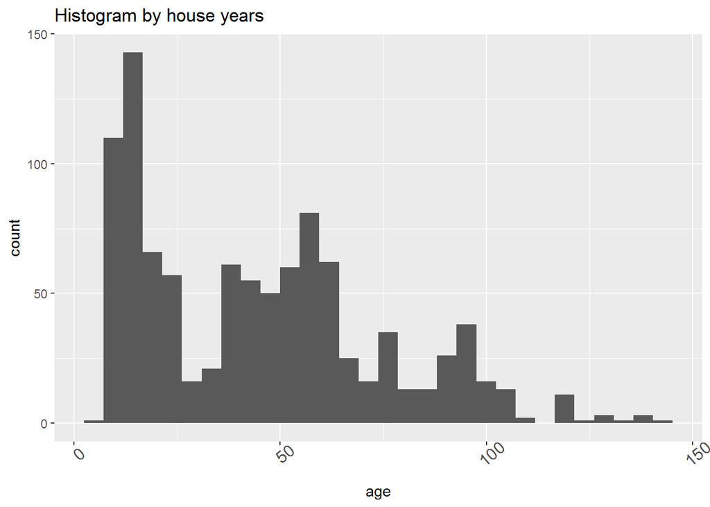

```r
ames_train %>%
  mutate(age=2017-Year.Built) %>%
  select(age) %>%
  ggplot(aes(x=age)) +
  geom_histogram(bins=30) +
  ggtitle("Histogram by house years") +
  theme(axis.text.x =   element_text(angle=40,  size=12))
```

The ages of the houses (taking 2017 as the actual value ) has a right skewed distribution.

# 2

The mantra in real estate is “Location, Location, Location!” Make a graphical display that relates a home price to its neighborhood in Ames, Iowa. Which summary statistics are most appropriate to use for determining the most expensive, least expensive, and most heterogeneous (having the most variation in housing price) neighborhoods? Report which neighborhoods these are based on the summary statistics of your choice. Report the value of your chosen summary statistics for these neighborhoods.

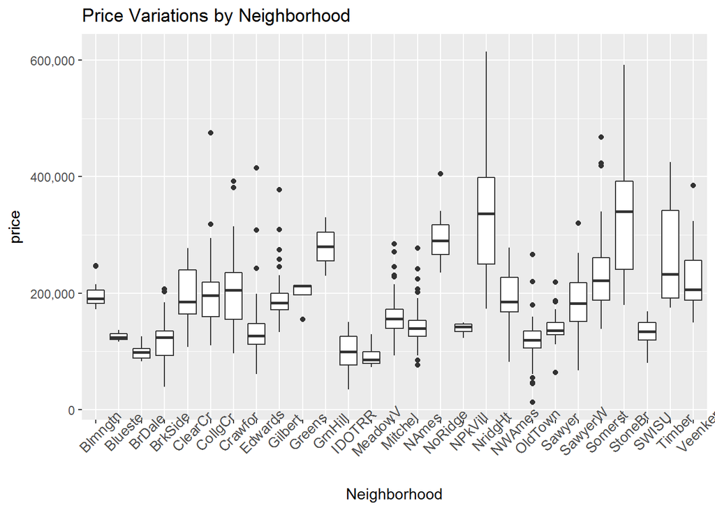

```r
ames_train %>%
  group_by(Neighborhood) %>%
  ggplot(aes(x=Neighborhood,y=price))+
  geom_boxplot() +
  ggtitle("Price Variations by Neighborhood") +
  theme(axis.text.x =   element_text(angle=45,  size=10)) +
   scale_y_continuous( labels = comma)
```

Box plot of price by neighborhood shows us at a simple glance the variations and help us to compare them in a simple way. Now we’ll compute a summary grouped by neighborhood.

```r
nbh_dist<- ames_train %>%
  group_by(Neighborhood) %>%
  summarise(max=max(price), min=min(price),average=mean(price),median=median(price),std=sd(price))
data.frame(nbh_dist)
```

```
##    Neighborhood    max    min   average   median       std
## 1       Blmngtn 246990 172500 198634.55 191000.0  26454.86
## 2       Blueste 137000 116500 125800.00 123900.0  10381.23
## 3        BrDale 125500  83000  98930.00  98750.0  13337.59
## 4       BrkSide 207000  39300 122472.56 124000.0  37309.91
## 5       ClearCr 277000 107500 193153.85 185000.0  48068.69
## 6       CollgCr 475000 110000 196950.86 195800.0  52786.08
## 7       Crawfor 392500  96500 204196.55 205000.0  71267.56
## 8       Edwards 415000  61500 136322.02 127250.0  54851.63
## 9       Gilbert 377500 133000 193328.02 183500.0  41190.38
## 10       Greens 214000 155000 198562.50 212625.0  29063.42
## 11      GrnHill 330000 230000 280000.00 280000.0  70710.68
## 12       IDOTRR 150909  34900  97620.69  99500.0  31530.44
## 13      MeadowV 129500  73000  92946.88  85750.0  18939.78
## 14      Mitchel 285000  93500 165013.64 156500.0  39682.94
## 15        NAmes 277500  76500 141355.97 139900.0  27267.97
## 16      NoRidge 405000 235000 295844.64 290000.0  35888.97
## 17      NPkVill 149900 123000 139275.00 142100.0  11958.37
## 18      NridgHt 615000 173000 333646.74 336860.0 105088.90
## 19       NWAmes 278000  82500 194093.90 185000.0  41340.50
## 20      OldTown 265979  12789 120225.61 120000.0  36429.69
## 21       Sawyer 219000  63900 139312.70 136000.0  21216.22
## 22      SawyerW 320000  67500 183101.00 182500.0  48354.36
## 23      Somerst 468000 139000 234595.88 221650.0  65199.49
## 24      StoneBr 591587 180000 339316.05 340691.5 123459.10
## 25        SWISU 169000  80000 130619.50 134000.0  27375.76
## 26       Timber 425000 175000 265192.16 232500.0  84029.57
## 27      Veenker 385000 150000 233650.00 205750.0  72545.41
```

Then we’ll select top values for min, max, avg and standard devation for price variable.

```r
nbh_dist %>% select(Neighborhood,max)  %>% top_n(1)
```

```
## # A tibble: 1 × 2
##   Neighborhood    max
##         <fctr>  <int>
## 1      NridgHt 615000
```

```r
nbh_dist %>% select(Neighborhood,min)  %>% top_n(-1)
```

```
## # A tibble: 1 × 2
##   Neighborhood   min
##         <fctr> <int>
## 1      OldTown 12789
```

```r
nbh_dist %>% select(Neighborhood,average)  %>% top_n(1)
```

```
## # A tibble: 1 × 2
##   Neighborhood average
##         <fctr>   <dbl>
## 1      StoneBr  339316
```

```r
nbh_dist %>% select(Neighborhood,std)  %>% top_n(1)
```

```
## # A tibble: 1 × 2
##   Neighborhood      std
##         <fctr>    <dbl>
## 1      StoneBr 123459.1
```

For this datset we can confirm that NridgHt has the more expensive house, Oldtown the cheapest. StoneBr has, in average, the more expensive houses and StoneBr has the more variable house price.

# 3

Which variable has the largest number of missing values? Explain why it makes sense that there are so many missing values for this variable.

```r
tmp<-data.frame(apply(ames_train, 2, function(x) length(which(is.na(x)))))
nas <- cbind(rownames(tmp),tmp);
rownames(nas)<-NULL;colnames(nas)<-c("Neighborhood","NAs")
nas %>% top_n(1)
```

```
##   Neighborhood NAs
## 1      Pool.QC 997
```

# 4

We want to predict the natural log of the home prices. Candidate explanatory variables are lot size in square feet (Lot.Area), slope of property (Land.Slope), original construction date (Year.Built), remodel date (Year.Remod.Add), and the number of bedrooms above grade (Bedroom.AbvGr). Pick a model selection or model averaging method covered in the Specialization, and describe how this method works. Then, use this method to find the best multiple regression model for predicting the natural log of the home prices.

We’ll create a variable that contains the required columns for creating the regression model.

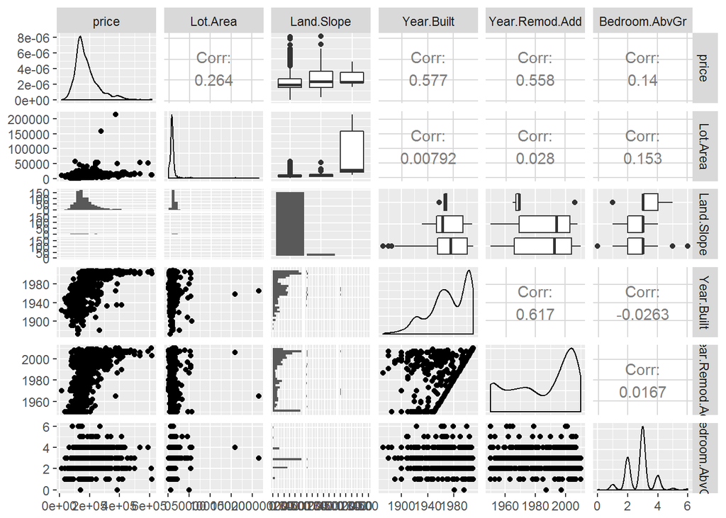

```r
mod_ds<-ames_train %>% select(price,Lot.Area,Land.Slope,Year.Built,Year.Remod.Add,Bedroom.AbvGr)
ggpairs(mod_ds)
```

The plot tells us about the relationship between all the columns.

Now we’ll create two different Bayesian models to analyse which colums to include in our model. The first model set the prior probablity as BIC and the second uses Zellner-Siow Cauchy prior.

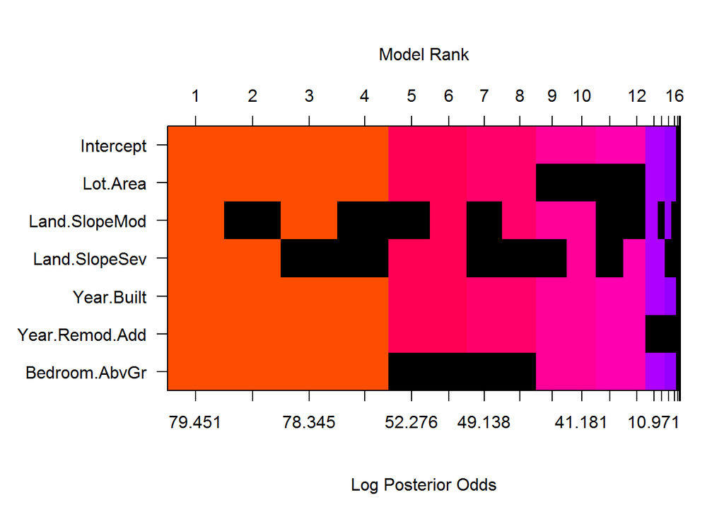

```r
 bma_mod_bic <- bas.lm(log(price) ~ . , data=mod_ds,prior = "BIC",
                                       modelprior = uniform())

image(bma_mod_bic,rotate=F)
```

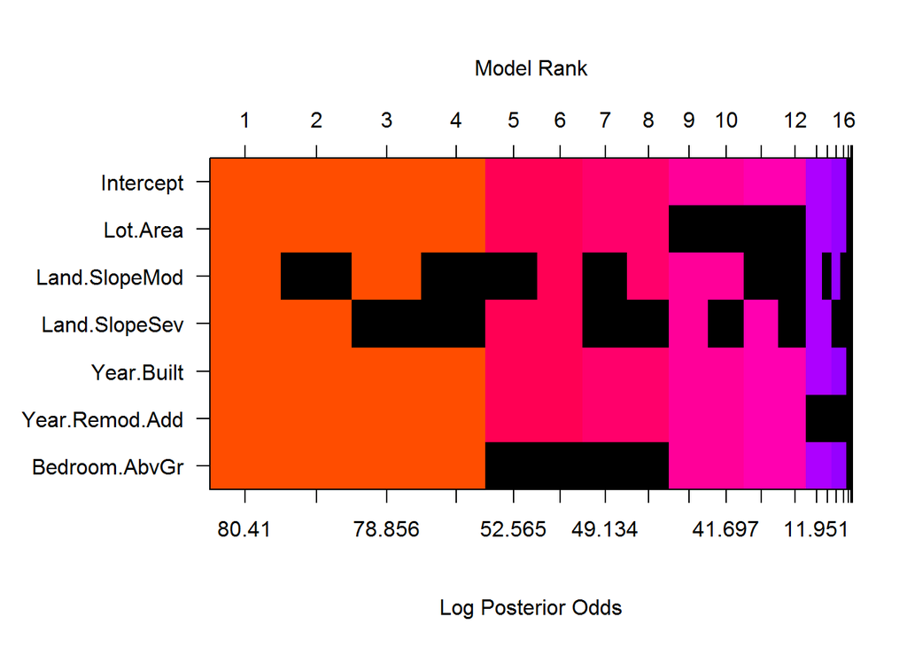

```r
bma_mod_zel <- bas.lm(log(price) ~ . ,
                  data=mod_ds,prior = "ZS-null",
                  modelprior = uniform())


image(bma_mod_zel,rotate=F)
```

We can see both model suggest to include all the columns and Zellner’s approach has greater posterior odds.

```r
summary(bma_mod_zel)
```

```
##      Intercept Lot.Area Land.SlopeMod Land.SlopeSev Year.Built
## [1,]         1        1             1             1          1
## [2,]         1        1             0             1          1
## [3,]         1        1             1             0          1
## [4,]         1        1             0             0          1
## [5,]         1        1             0             1          1
##      Year.Remod.Add Bedroom.AbvGr           BF PostProbs     R2 dim
## [1,]              1             1 1.000000e+00    0.5945 0.5625   7
## [2,]              1             1 4.240805e-01    0.2521 0.5591   6
## [3,]              1             1 2.112883e-01    0.1256 0.5585   6
## [4,]              1             1 4.677786e-02    0.0278 0.5544   5
## [5,]              1             0 8.073463e-13    0.0000 0.5316   5
##       logmarg
## [1,] 391.7282
## [2,] 390.8704
## [3,] 390.1737
## [4,] 388.6659
## [5,] 363.8832
```

Based on aour analysis we’ll choose bma_mod_zel model that explains 56.2% of the variablity. The highest value of all the possible models.

# 5

Which home has the largest squared residual in the previous analysis (Question 4)? Looking at all the variables in the data set, can you explain why this home stands out from the rest (what factors contribute to the high squared residual and why are those factors relevant)?

```r
lm_price <- lm(log(price)~Lot.Area+Land.Slope+Year.Built+Year.Remod.Add+Bedroom.AbvGr , data= mod_ds)
resDF<-data.frame(residuals=(abs(lm_price$residuals))^2)
mod_ds_res<-cbind(mod_ds ,resDF)
mod_ds_res %>% arrange(desc(residuals)) %>% head(1)
```

```
##   price Lot.Area Land.Slope Year.Built Year.Remod.Add Bedroom.AbvGr
## 1 12789     9656        Gtl       1923           1970             2
##   residuals
## 1   4.35913
```

We’ve created a linear model including 6 columns, then we’ve got the squared residuals. This home stands out from the rest mostly because it was built befor than 1930.

# 6

Use the same model selection method you chose in Question 4 to again find the best multiple regression model to predict the natural log of home prices, but this time **replacing Lot.Area with log(Lot.Area)**. Do you arrive at a model including the same set of predictors?

In order to answer this we’ll create two new models (prior BIC and Zellner) but our explanatory variable Lot.Area will be treated as a natural log to evaluate how the model behaves and what should we keep or remove.

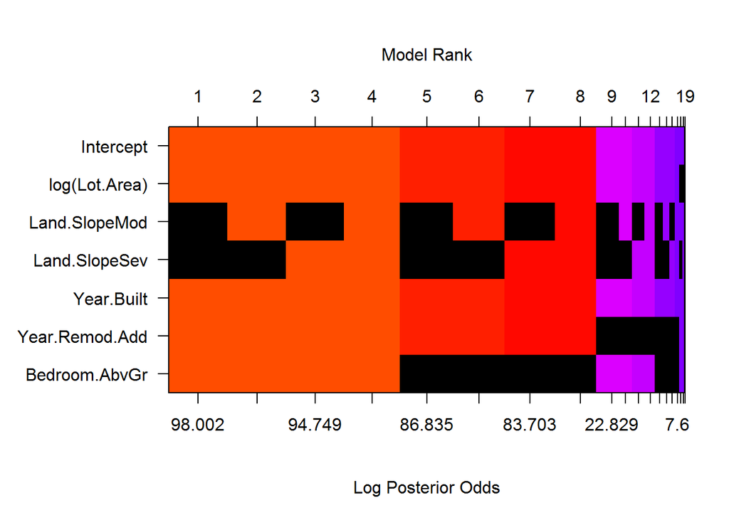

```r
bma_mod_bic_log <- bas.lm(log(price) ~log( Lot.Area)+Land.Slope+Year.Built+Year.Remod.Add+Bedroom.AbvGr ,
                      data=mod_ds,prior = "BIC",
                      modelprior = uniform())

image(bma_mod_bic_log,rotate=F)
```

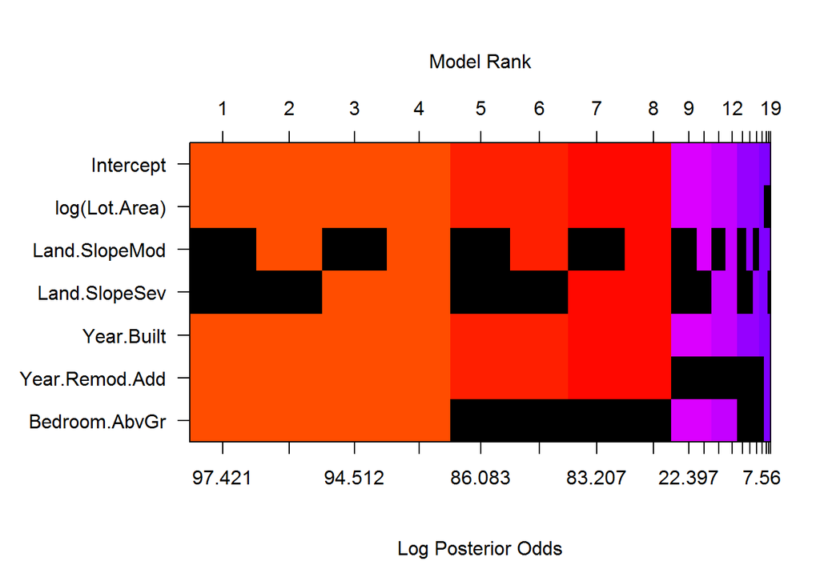

```r
bma_mod_zel_log <- bas.lm(log(price) ~ log(Lot.Area)+Land.Slope+Year.Built+Year.Remod.Add+Bedroom.AbvGr ,
                      data=mod_ds,prior = "ZS-null",  #Zellner-Siow Cauchy prior
                      modelprior = uniform())


image(bma_mod_zel_log,rotate=F)
```

Checking both models, they suggest to remove Land.Slope as a predictor of log(price). So our final model won’t contain Land.Slope and will have BIC as priori because of the greater posteriors odds.

# 7

Do you think it is better to log transform Lot.Area, in terms of assumptions for linear regression? Make graphs of the predicted values of log home price versus the true values of log home price for the regression models selected for Lot.Area and log(Lot.Area). Referencing these two plots, provide a written support that includes a quantitative justification for your answer in the first part of question 7.

Let’s create the final models with and without log transformation for Lot.Area.

```r
bma_mod_zel_log_final <- bas.lm(log(price) ~ log(Lot.Area)+Year.Built+Year.Remod.Add+Bedroom.AbvGr ,
                      data=mod_ds,prior = "BIC",
                      modelprior = uniform())
bma_mod_zel_final <- bas.lm(log(price) ~ Lot.Area+Year.Built+Year.Remod.Add+Bedroom.AbvGr ,
                      data=mod_ds,prior = "BIC",
                      modelprior = uniform())
```

Now let’s plot prediction and residuals for each model.

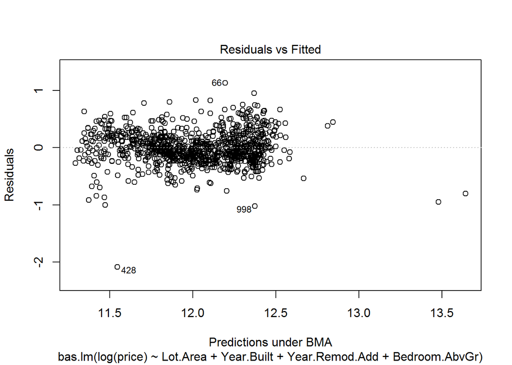

```r
plot(bma_mod_zel_final, which=1, add.smooth=F)
```

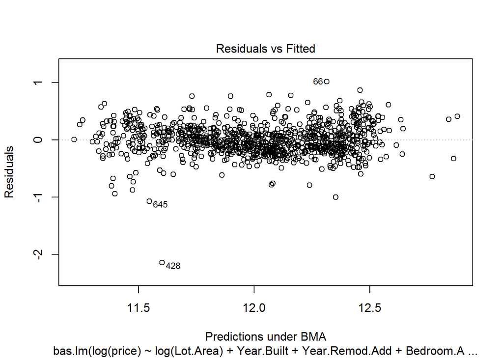

```r
plot(bma_mod_zel_log_final, which=1, add.smooth=F)
```

So by log transforming Lot.Area we can see we’ve reduced residuals variability’

### 7.0.1